# L04 Maps

Data Visualization (STAT 302)

Author

INSTRUCTIONS

## Overview

The goal of this lab is to explore various ways of building maps with `ggplot2`.

Challenges are not mandatory for students to complete. We highly recommend students attempt them though. *We would expect graduate students to attempt the challenges.*

## Datasets

We’ll be using the `US_income.rda` dataset which should be placed in the `/data` subdirectory in our **data_vis_labs** project. You’ll also be downloading your own data to build maps.

## Exercise 1

### Plot 1

Make a county map of a US state using `geom_polygon()`. Maybe use your home state or a favorite state. Please do NOT use the state in the ggplot2 book example.

Optional: Consider adding major cities (or your home town).

*Hints:*

- See section [6.1](https://ggplot2-book.org/maps.html#polygonmaps) in our book.
- Void theme

[figure not shown]

### Plot 2

Now use `geom_sf()` instead. You’ll need to download data for this. You can use either the `tigris` ([github page](https://github.com/walkerke/tigris)) or `geodata` packages. Either `tigris`’ `counties()` with `cb = TRUE` or `geodata`’s `gadm()` could be useful.

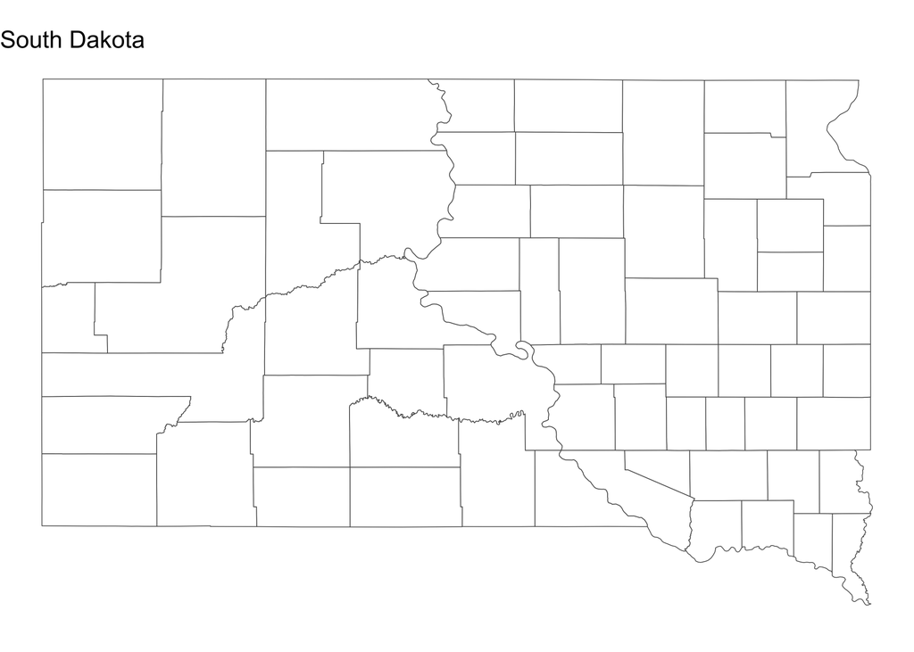

## Exercise 2

Using the `US_income` dataset, recreate the following graphics as precisely as possible.

### Plot 1

*Hints:*

- `geom_sf()` — boundary color is `"grey80"` and size is 0.2
- `viridis` package (`discrete = TRUE` in `scale_*` function)
- Void theme

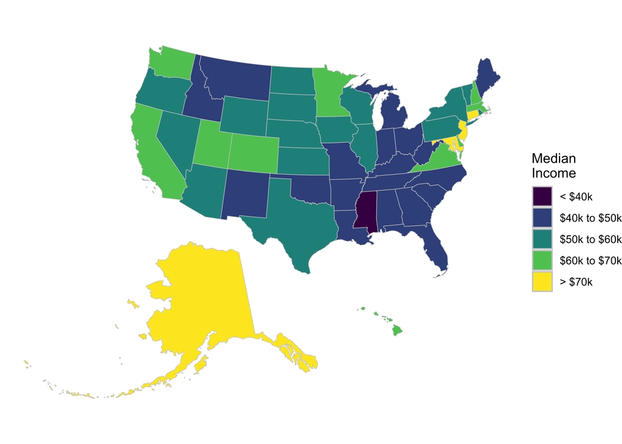

### Plot 2

*Hints:*

- `statebins::geom_statebins()`
- `viridis` package (`discrete = TRUE` in `scale_*` function)
- Statebins theme

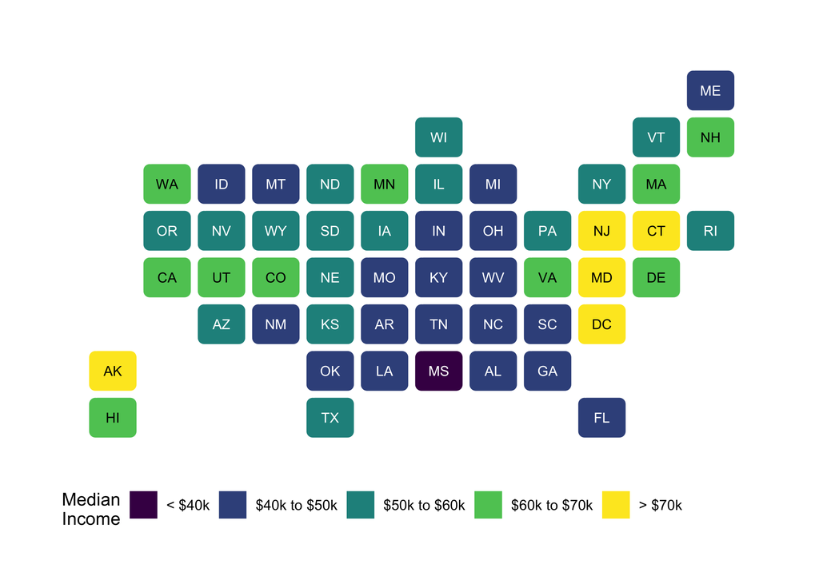

## Exercise 3

Pick any city or foreign country to build a map for. You can dress it up or make it as basic as you want. Also welcome to try building a graphic like that depicted at the end of section [6.5](https://ggplot2-book.org/maps.html#rastermaps) — use a different region though.

## Challenge(s)

**Optional**

Using the `tidycensus` package and few others, try to create a map like below using [these directions](https://walkerke.github.io/tidycensus/articles/spatial-data.html). Try using a different geographical area and a different variable from the ACS.

[interactive chart not shown]